# Splines in time ordering - validation check

Kushal K Dey

January 16, 2016

## Background

The goal of this study is to apply cubic splines and B splines smoothing on cell-cycle or time series data. The main reasons for this validation check is to figure out how good the model fits the true ordered data compared to randomly ordered data. Also, time complexity is a big issue. The other candidate models to using Splines would be using a kernel smoother like LOESS or to use wavelets.

## Simulation from sinusoidal model

```r
library(cellcycleR)
library(wavethresh)
G <- 100;
num_cells <- 256;
amp_genes1 <- rep(10, G);
phi_genes1 <- rep(c(2,5), each=G/2);
sigma_genes1 <- rchisq(G, 4);
cell_times_sim <- sort(sample(seq(0,2*pi, 2*pi/(num_cells-1)), num_cells, replace=FALSE));
cycle_data <- t(sim_sinusoidal_cycle(G, amp_genes1, phi_genes1, sigma_genes1, cell_times_sim));
```

The sinusoidal expression pattern for $1$st gene

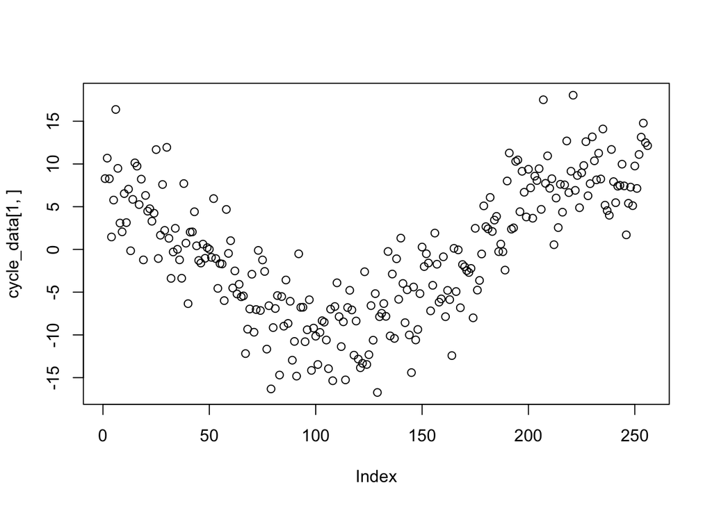

```r
plot(cycle_data[1,])
```

## Permutation of sample labels

Now we permute the labels of the times.

```r
sample_reorder <- sample(1:num_cells,num_cells, replace=FALSE);
cycle_data_reorder <- cycle_data[,sample_reorder];
```

We plot the expression pattern for $1$st gene.

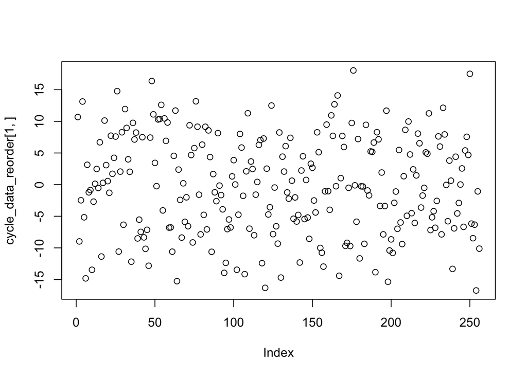

```r
plot(cycle_data_reorder[1,])
```

## Applying B-splines

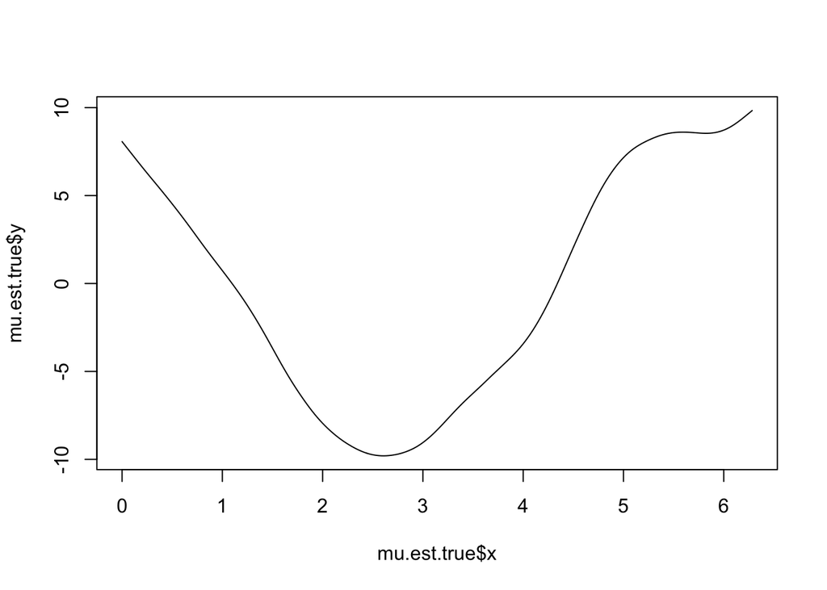

```r
mu.est.true <- smooth.spline(cell_times_sim, cycle_data[1,])
plot(mu.est.true, type = "l")
```

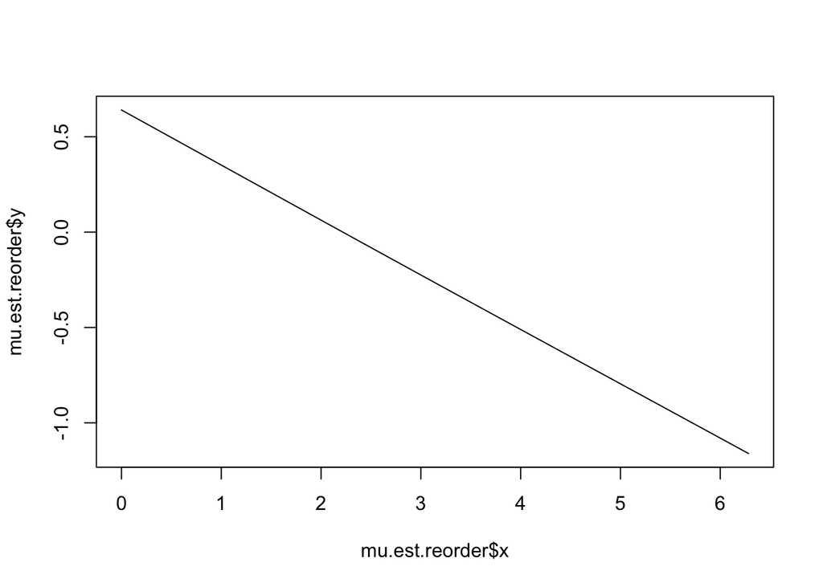

```r
mu.est.reorder <- smooth.spline(cell_times_sim, cycle_data_reorder[1,])
plot(mu.est.reorder, type = "l")
```

We then find the deviation of true observations against the fitted mean value from the above method.

```r
disp_reorder <- sum((cycle_data_reorder[1,] - mu.est.reorder$y)^2)
disp_true <- sum((cycle_data[1,] - mu.est.true$y)^2)
```

## Validation of procedure

But this was for one gene only. We can find the average dispersion across all the genes.

```r
disp.true <- array(0,G);
system.time(smash_disp_true <- mean(sapply(1:G, function(g)
                               {
                                  mu.est.true <- smooth.spline(cell_times_sim, cycle_data[g,])
                                  out <- sum((cycle_data[g,] - mu.est.true$y)^2)
                                  return(out)
                               })))
```

```
##    user  system elapsed
##   0.094   0.003   0.098
```

```r
library(parallel)
system.time(outdisp_set <- unlist(mclapply(1:20, function(l)
               {
                  sample_reorder <- sample(1:num_cells,num_cells, replace=FALSE);
                  cycle_data_reorder <- cycle_data[,sample_reorder];
                  disp <- mean(sapply(1:G, function(g)
                               {
                                  mu.est.reord <- smooth.spline(cell_times_sim, cycle_data_reorder[g,])
                                  out <- sum((cycle_data_reorder[g,] - mu.est.reord$y)^2)
                                  return(out)
                               }))
                  return(disp)
                }, mc.cores=detectCores())))
```

```
##    user  system elapsed
##   2.526   0.121   0.955
```

The dispersion set of values for re-ordered data (not true order) after repeating the re-ordering $20$ times

```r
print(outdisp_set)
```

```
##  [1] 18110.22 18223.36 18051.59 18371.72 18235.37 18348.57 18009.11
##  [8] 18215.40 17833.56 18382.17 18320.16 18060.91 18169.90 18346.24
## [15] 18390.98 17187.78 18318.56 18109.46 17874.59 18250.90
```

The true value of dispersion corresponding to true ordering

```r
print(smash_disp_true)
```

```
## [1] 5506.816
```